# Bird beak’s elaboration and exploration: data preparation

Thomas Guillerme

2022-03-10

The method described in the next three markdown is essentially a mini chains with pseudo-metropolis coupling markov chain generalised linear mixed model method to determine clades and tips elaboration and exploration (`mcmcpmcmcmcglmmmctee`) but we will refrain using this acronym and method name.

```r
## Installing the dispRity branch
devtools::install_github("TGuillerme/dispRity@MCMCglmm")
```

```r
## Loading packages
library(dispRity) #v>=1.7
```

# Data preparation

TODO:

- [ ] what’s the data, where is it from
- [ ] Procrustes
- [ ] Building the trait space
  - [ ] form space version?
  - [ ] shape space version?
- [ ] Clade data and grouping

Trees were manipulated in `R` (R Core Team 2021) using the package `ape` (Paradis and Schliep 2019).

- The trait space

```r
## Reading the different trait spaces
shapespace <- readRDS("../Data/Raw/Beak_data/2020_08_07_MMB_MORPHO_SHAPESPACE_FULL.rds")
shapespace <- shapespace$PCscores
formspace <- readRDS("../Data/Raw/Beak_data/2020_08_07_MMB_MORPHO_FORMSPACE_FULL.rds")
formspace <- formspace$PCscores
```

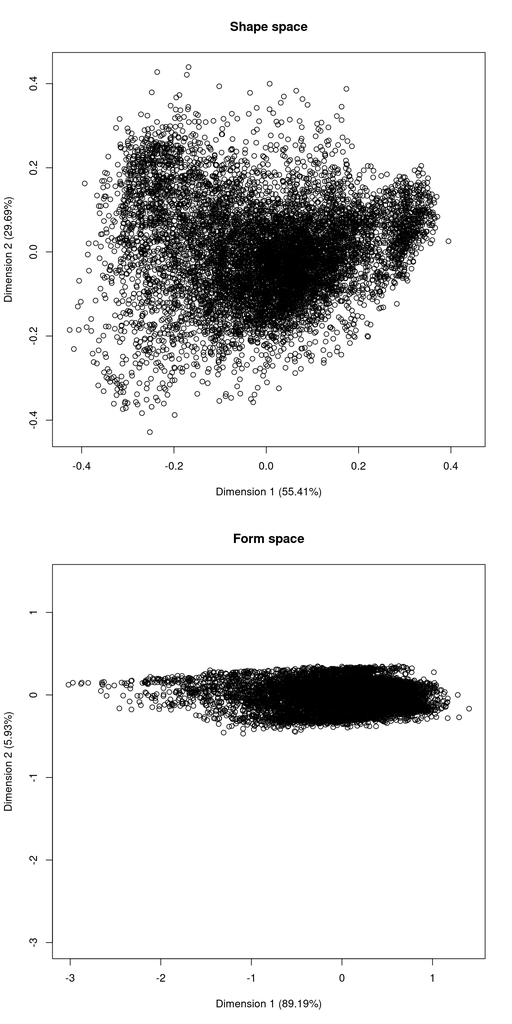

- The tree(s)

```r
## Reading the consensus tree
consensus_tree <- read.nexus("../Data/Raw/Tree_data/9993taxa_1_tree_Global_MCC_CA.tre")

## Reading the distribution of trees
trees_list <- read.tree("../Data/Raw/Tree_data/AllBirdsHackett1.tre")
```

```r
## Reading the clades list
clades_list <- as.data.frame(read.csv("../Data/Raw/BirdClades.csv", row.names = 1, stringsAsFactors = TRUE))
## Remove the absent species
clades_list <- clades_list[rownames(clades_list) %in% rownames(shapespace), ]
## Sorting the list by rownames from the shapespace
clades_list <- clades_list[match(rownames(shapespace), rownames(clades_list)), -c(6, 7)]
## Renaming the levels
colnames(clades_list) <- c("superorder", "order", "suborder", "superfamily", "family")

## Cleaning the levels (removing any level with less than 15 elements)
update.level <- function(level, min = 15) {
    to_remove <- which(table(level) < min)
    remove_table <- data.frame("clade" = names(to_remove), "species" =  c(table(level)[to_remove]))
    level[which(level %in% c(names(to_remove)))] <-  ""
    return(list(level = as.factor(as.character(level)), removed = remove_table))
}

## Updated list
update_clade_list <- lapply(as.list(clades_list), update.level, min = 15)
clade_list <- data.frame(lapply(update_clade_list, `[[`, 1))
removed_table <- do.call(rbind, lapply(update_clade_list, function(x) {rownames(x$removed) <- NULL; return(x$removed)}))

## Saving the clade list
save(clade_list, file = "../Data/Processed/clade_list.rda")
```

List of removed clades by level and number of species in that clade in the dataset.

|  | clade | species |
| --- | --- | --- |
| superorder | Eurypygimorphae | 5 |
| order.1 | Apterygiformes | 4 |
| order.2 | Cariamiformes | 2 |
| order.3 | Casuariiformes | 4 |
| order.4 | Coliiformes | 6 |
| order.5 | Eurypygiformes | 2 |
| order.6 | Gaviiformes | 5 |
| order.7 | Leptosomiformes | 1 |
| order.8 | Mesitornithiformes | 3 |
| order.9 | Opisthocomiformes | 1 |
| order.10 | Phaethontiformes | 3 |
| order.11 | Phoenicopteriformes | 6 |
| order.12 | Rheiformes | 2 |
| order.13 | Struthioniformes | 1 |
| suborder.1 | Acanthisitti | 2 |
| suborder.2 | Pelecani | 9 |
| suborder.3 | Upupi | 9 |
| superfamily.1 | Bombycilloidea | 10 |
| superfamily.2 | Muscicapoidea | 1 |
| superfamily.3 | Stenostiridae | 1 |
| family.1 | Acanthisittidae | 2 |
| family.2 | Aegithinidae | 4 |
| family.3 | Aegothelidae | 3 |
| family.4 | Anhimidae | 3 |
| family.5 | Anhingidae | 4 |
| family.6 | Anseranatidae | 1 |
| family.7 | Apterygidae | 4 |
| family.8 | Aramidae | 1 |
| family.9 | Artamidae | 11 |
| family.10 | Atrichornithidae | 2 |

[output cut: 91 more lines]

### Selecting the number of axes

How many dimensions do we need to represent at least 95% of the variance in each group

```r
## Temporary change the empty levels to noclade
clades <- clades_list[, c(1)]
levels(clades)[1] <- "noclade"

## Make a dispRity object and get axes data
shape_axes <- select.axes(custom.subsets(shapespace, group = clades))
form_axes  <- select.axes(custom.subsets(formspace, group = clades))
```

variance per axes for the Shape space

|  | PC1.var | PC1.sum | PC2.var | PC2.sum | PC3.var | PC3.sum | PC4.var | PC4.sum | PC5.var | PC5.sum | PC6.var | PC6.sum | PC7.var | PC7.sum | PC8.var | PC8.sum | PC9.var | PC9.sum |
| --- | --- | --- | --- | --- | --- | --- | --- | --- | --- | --- | --- | --- | --- | --- | --- | --- | --- | --- |
| noclade | 0.504 | 0.504 | 0.339 | 0.843 | 0.078 | 0.921 | 0.025 | 0.945 | 0.015 | 0.961 | 0.008 | 0.969 | 0.010 | 0.979 | 0.006 | 0.984 | 0.003 | 0.987 |
| Aequornithes | 0.384 | 0.384 | 0.375 | 0.759 | 0.075 | 0.834 | 0.030 | 0.864 | 0.020 | 0.884 | 0.011 | 0.895 | 0.047 | 0.942 | 0.017 | 0.959 | 0.014 | 0.972 |
| Columbimorphae | 0.293 | 0.293 | 0.456 | 0.750 | 0.093 | 0.843 | 0.040 | 0.883 | 0.016 | 0.899 | 0.040 | 0.938 | 0.019 | 0.957 | 0.005 | 0.962 | 0.006 | 0.968 |
| Eurypygimorphae | 0.440 | 0.440 | 0.146 | 0.586 | 0.266 | 0.852 | 0.005 | 0.857 | 0.038 | 0.896 | 0.039 | 0.934 | 0.026 | 0.960 | 0.003 | 0.964 | 0.003 | 0.966 |
| Galloanserae | 0.253 | 0.253 | 0.401 | 0.653 | 0.141 | 0.795 | 0.118 | 0.912 | 0.032 | 0.944 | 0.011 | 0.955 | 0.009 | 0.964 | 0.010 | 0.974 | 0.004 | 0.978 |
| Mirandornithes | 0.124 | 0.124 | 0.337 | 0.461 | 0.040 | 0.501 | 0.313 | 0.814 | 0.089 | 0.902 | 0.006 | 0.908 | 0.057 | 0.965 | 0.017 | 0.982 | 0.004 | 0.986 |
| Otidimorphae | 0.401 | 0.401 | 0.396 | 0.797 | 0.090 | 0.887 | 0.051 | 0.938 | 0.013 | 0.951 | 0.021 | 0.972 | 0.007 | 0.979 | 0.004 | 0.983 | 0.003 | 0.986 |
| Paleognathae | 0.363 | 0.363 | 0.402 | 0.766 | 0.133 | 0.899 | 0.027 | 0.926 | 0.018 | 0.944 | 0.028 | 0.972 | 0.008 | 0.980 | 0.002 | 0.982 | 0.003 | 0.985 |
| Strisores | 0.712 | 0.712 | 0.226 | 0.938 | 0.024 | 0.961 | 0.024 | 0.985 | 0.003 | 0.988 | 0.004 | 0.992 | 0.002 | 0.994 | 0.002 | 0.996 | 0.001 | 0.997 |
| Telluraves | 0.511 | 0.511 | 0.341 | 0.851 | 0.073 | 0.924 | 0.021 | 0.945 | 0.014 | 0.959 | 0.014 | 0.974 | 0.008 | 0.982 | 0.004 | 0.986 | 0.003 | 0.989 |
| whole_space | 0.554 | 0.554 | 0.297 | 0.851 | 0.066 | 0.917 | 0.028 | 0.945 | 0.016 | 0.962 | 0.011 | 0.973 | 0.009 | 0.982 | 0.004 | 0.987 | 0.003 | 0.989 |

variance per axes for the Form space

|  | PC1.var | PC1.sum | PC2.var | PC2.sum | PC3.var | PC3.sum | PC4.var | PC4.sum | PC5.var | PC5.sum | PC6.var | PC6.sum | PC7.var | PC7.sum | PC8.var | PC8.sum |
| --- | --- | --- | --- | --- | --- | --- | --- | --- | --- | --- | --- | --- | --- | --- | --- | --- |
| noclade | 0.915 | 0.915 | 0.038 | 0.953 | 0.032 | 0.986 | 0.007 | 0.992 | 0.003 | 0.995 | 0.001 | 0.996 | 0.001 | 0.997 | 0.001 | 0.998 |
| Aequornithes | 0.951 | 0.951 | 0.012 | 0.963 | 0.020 | 0.983 | 0.008 | 0.990 | 0.002 | 0.992 | 0.001 | 0.993 | 0.001 | 0.994 | 0.003 | 0.997 |
| Columbimorphae | 0.792 | 0.792 | 0.061 | 0.853 | 0.099 | 0.952 | 0.015 | 0.967 | 0.009 | 0.977 | 0.003 | 0.979 | 0.008 | 0.988 | 0.004 | 0.991 |
| Eurypygimorphae | 0.424 | 0.424 | 0.272 | 0.696 | 0.097 | 0.793 | 0.129 | 0.923 | 0.006 | 0.929 | 0.013 | 0.942 | 0.021 | 0.963 | 0.014 | 0.978 |
| Galloanserae | 0.863 | 0.863 | 0.026 | 0.889 | 0.058 | 0.948 | 0.028 | 0.975 | 0.013 | 0.989 | 0.003 | 0.992 | 0.002 | 0.993 | 0.001 | 0.995 |
| Mirandornithes | 0.911 | 0.911 | 0.009 | 0.920 | 0.028 | 0.948 | 0.003 | 0.951 | 0.034 | 0.985 | 0.005 | 0.991 | 0.001 | 0.991 | 0.005 | 0.997 |
| Otidimorphae | 0.856 | 0.856 | 0.056 | 0.912 | 0.059 | 0.971 | 0.012 | 0.983 | 0.008 | 0.991 | 0.001 | 0.993 | 0.003 | 0.996 | 0.001 | 0.997 |
| Paleognathae | 0.928 | 0.928 | 0.022 | 0.951 | 0.032 | 0.982 | 0.011 | 0.993 | 0.002 | 0.995 | 0.001 | 0.996 | 0.002 | 0.998 | 0.001 | 0.999 |
| Strisores | 0.649 | 0.649 | 0.238 | 0.887 | 0.086 | 0.973 | 0.012 | 0.985 | 0.010 | 0.995 | 0.001 | 0.996 | 0.001 | 0.997 | 0.001 | 0.998 |
| Telluraves | 0.869 | 0.869 | 0.069 | 0.938 | 0.044 | 0.983 | 0.007 | 0.990 | 0.003 | 0.993 | 0.002 | 0.995 | 0.002 | 0.997 | 0.001 | 0.998 |
| whole_space | 0.892 | 0.892 | 0.059 | 0.951 | 0.033 | 0.985 | 0.006 | 0.991 | 0.003 | 0.994 | 0.002 | 0.996 | 0.001 | 0.997 | 0.001 | 0.998 |

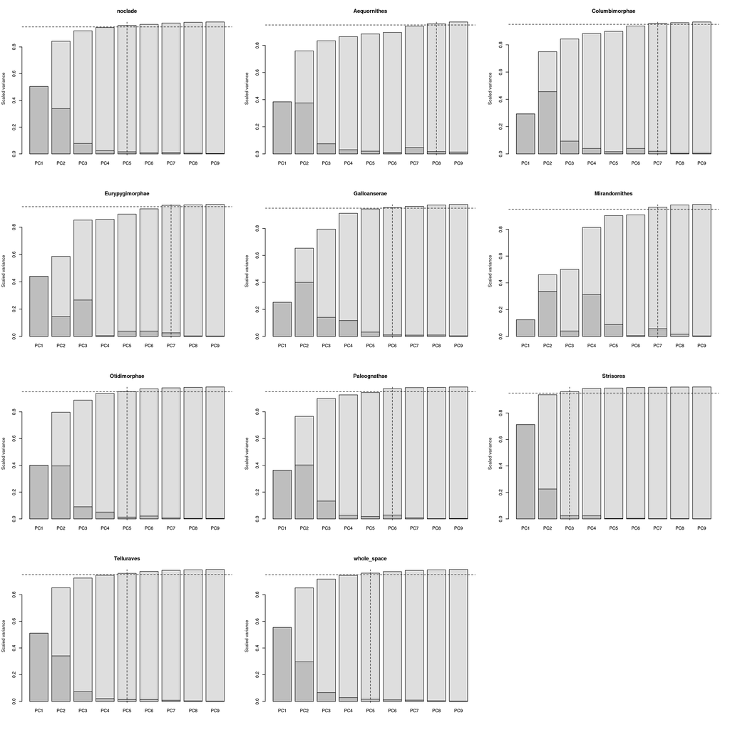

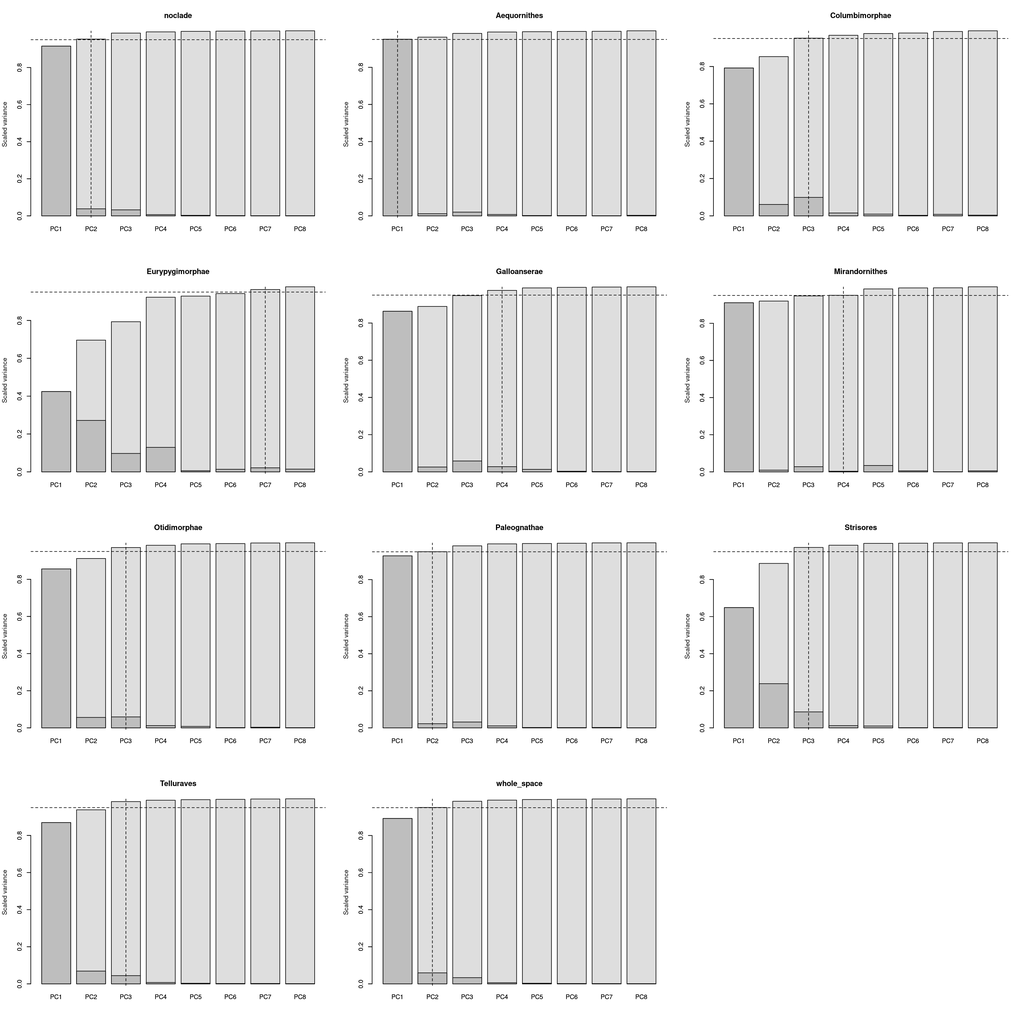

By analysing the distribution of the variance within each group, we will need 8 dimensions for the shape space and 7 for the form space.

### Saving the data

Here we are going to group the spaces, trees and levels for subsequent levels (nested). There are 5 levels: Super order (1), Order (2), Sub-order (3), Super families (4) and families (5). The script above creates the model for the two first levels, the subsequent models create the mini-chains for the following overlapping pairs of models (order + sub-order; sub-order + super families; super families + families).

```r
source("../Functions/prep.data.R")
## Getting the data ready for all birds
shapespace_allbirds_lvl_superorder_order <- prep.data(
                                          level = 0, lvl.inc = c(1,2),
                                          clades    = clades_list,
                                          space     = shapespace,
                                          dim       = shape_axes$dimensions,
                                          consensus = consensus_tree,
                                          trees     = trees_list,
                                          verbose   = TRUE)
```

```
## Separating the trees:.Done.
## Preparing the levels:.Done.
## Preparing the spaces:.Done.
```

```r
save(shapespace_allbirds_lvl_superorder_order, file = "../Data/Processed/shapespace_allbirds_lvl_superorder_order.rda")

## Getting the data ready for each bird super order
shapespace_superorder_lvl_order_suborder <- prep.data(
                                          level = 1, lvl.inc = c(2,3),
                                          clades    = clades_list,
                                          space     = shapespace,
                                          dim       = shape_axes$dimensions,
                                          consensus = consensus_tree,
                                          trees     = trees_list,
                                          verbose   = TRUE)
```

```
## Separating the trees:........Done.
## Preparing the levels:........Done.
## Preparing the spaces:........Done.
```

```r
save(shapespace_superorder_lvl_order_suborder, file = "../Data/Processed/shapespace_superorder_lvl_order_suborder.rda")

## Getting the data ready for each bird order
shapespace_order_lvl_suborder_superfam <- prep.data(
                                          level = 2, lvl.inc = c(3,4),
                                          clades    = clades_list,
                                          space     = shapespace,
                                          dim       = shape_axes$dimensions,
                                          consensus = consensus_tree,
                                          trees     = trees_list,
                                          verbose   = TRUE)
```

```
## Separating the trees:...........................Done.
## Preparing the levels:...........................Done.
## Preparing the spaces:...........................Done.
```

```r
save(shapespace_order_lvl_suborder_superfam, file = "../Data/Processed/shapespace_order_lvl_suborder_superfam.rda")

## Getting the data ready for each bird sub order
shapespace_suborder_lvl_superfam_fam <- prep.data(
                                          level = 3, lvl.inc = c(4,5),
                                          clades    = clades_list,
                                          space     = shapespace,
                                          dim       = shape_axes$dimensions,
                                          consensus = consensus_tree,
                                          trees     = trees_list,
                                          verbose   = TRUE)
```

```
## Separating the trees:............Done.
## Preparing the levels:............Done.
## Preparing the spaces:............Done.
```

```r
save(shapespace_suborder_lvl_superfam_fam, file = "../Data/Processed/shapespace_suborder_lvl_superfam_fam.rda")

## Getting the data ready for each bird super family
shapespace_superfam_lvl_fam <- prep.data(
                                          level = 4, lvl.inc = 5,
                                          clades    = clades_list,
                                          space     = shapespace,
                                          dim       = shape_axes$dimensions,
                                          consensus = consensus_tree,
                                          trees     = trees_list,
                                          verbose   = TRUE)
```

```
## Separating the trees:....Done.
## Preparing the levels:....Done.
## Preparing the spaces:....Done.
```

```r
save(shapespace_superfam_lvl_fam, file = "../Data/Processed/shapespace_superfam_lvl_fam.rda")

## Get a list of all selected levels for the record (and number of elements per levels)
super_orders     <- shapespace_allbirds_lvl_superorder_order[[1]]$levels[[1]]
orders           <- shapespace_allbirds_lvl_superorder_order[[1]]$levels[[2]]
sub_orders       <- lapply(shapespace_order_lvl_suborder_superfam, function(x) x$levels[[1]])
names(sub_orders) <- NULL
sub_orders       <- unlist(sub_orders, recursive = FALSE)
super_families   <- lapply(shapespace_order_lvl_suborder_superfam, function(x) x$levels[[2]])
names(super_families) <- NULL
super_families   <- unlist(super_families, recursive = FALSE)
families         <- lapply(shapespace_superfam_lvl_fam, function(x) x$levels[[1]])
names(families) <- NULL
families         <- unlist(families, recursive = FALSE)

## Get the list of levels
levels_list <- list("super_orders"   = unlist(lapply(super_orders, length)),
                    "orders"         = unlist(lapply(orders, length)),
                    "sub_orders"     = unlist(lapply(sub_orders, length)),
                    "super_families" = unlist(lapply(super_families, length)),
                    "families"       = unlist(lapply(families, length)))
save(levels_list, file = "../Data/Processed/levels_list.rda")
```

## References

Paradis, E., and K. Schliep. 2019. “Ape 5.0: An Environment for Modern Phylogenetics and Evolutionary Analyses in R.” *Bioinformatics* 35: 526–28.

R Core Team. 2021. *R: A Language and Environment for Statistical Computing*. Vienna, Austria: R Foundation for Statistical Computing. https://www.R-project.org/.